# Monitor calibration protocol

Andrea Seisler, Yiming Qian, & Rick Gilmore

2020-01-30 09:33:14

### Prepare Computer

- Log into Data Collection Computer in room 503B
  - Turn on the power of the data collection computer
  - Turn on the CRT monitor
  - Log-in (use your indiviual PSU login)

### Prepare Photometer

- Take the photometer out of the box.
- Set it up by plugging in the power and the light meter.
- Turn on the photometer

[figure not shown]

### Input the New Factor

**Only when photometer sent for Calibration ~every 3 years

[figure not shown]

### Zero Photometer

- Place the cap on the light meter
- Press the **ZERO** button
- Change to **DATA** Display
  - The reading should be 0.00
- Press the **ZERO** button
- Wait for the **DC** button to light up again.

### Start Calibrating Luminance

- Start Psychopy - Click icon on Task Bar
- Open Monitor Settings - Go to Tools > Monitor Center

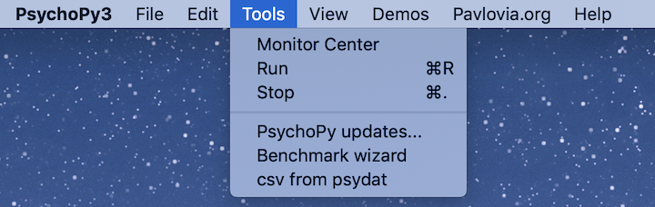

- Enter the Monitor Info

[figure not shown]

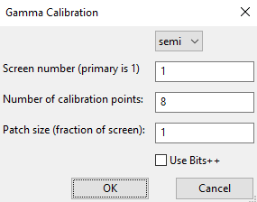

- Press **OK**
  - Follow instructions on the screen
  - record the values for each luminance value on paper
  - Note, the first value is the **0** value for lum, R, G, and B so there will be 7 values for lum, R, G, and B after that.
- At the end of the stimuli, a Luminance Values Box will appear.

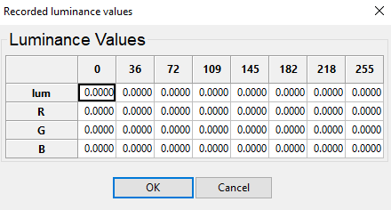

- Enter the Luminance Values determined from the Photometer and recorded on paper.

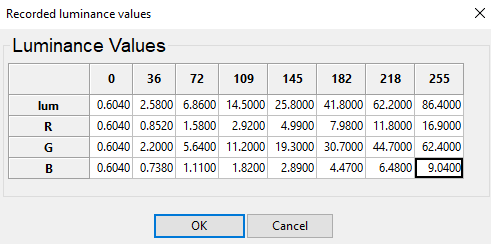

- Select **OK**
- Enter the Current Date for the filename.

### Calibration Results for Mitsibushi Monitor 01-28-2020

|  | 0 | 36 | 72 | 109 | 145 | 182 | 218 | 255 |  |
| --- | --- | --- | --- | --- | --- | --- | --- | --- | --- |
| lum | 0.604 | 2.58 | 6.86 | 14.5 | 25.8 | 41.8 | 62.2 | 86.4 |  |
| R | 0.604 | 0.852 | 1.58 | 2.92 | 4.99 | 7.98 | 11.8 | 16.9 |  |
| G | 0.604 | 2.20 | 5.64 | 11.2 | 19.3 | 30.7 | 44.7 | 62.4 |  |
| B | 0.604 | 0.738 | 1.11 | 1.82 | 2.89 | 4.47 | 6.48 | 9.04 |  |

#### Gamma Function of Calibration 01-28-2020

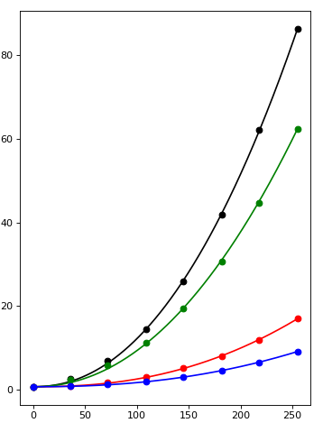

#### Black/White/Grey

- A separate script was run to get Black, White and Grey values for the phototmeter to compare to other studies.

[output not shown]